```python
%matplotlib inline
import matplotlib.pyplot as plt

import seaborn as sns
import pandas as pd
import statsmodels.api as sm
import numpy as np
import warnings
warnings.filterwarnings('ignore')
pd.set_option('display.max_columns', None)
```

# *Computing Lab Assignment 1 - Sebastian Wolf*

# Report to the mayor of London: Traffic accidents and risk factors

The mayor of London has asked for a report on road safety in the City of London. She/he wants the report to include answers to the following questions:

```
- Is road safety improving or getting worse?
- Who is most affected?
- Which areas and which times do we see the most accidents?
```

To answer the mayor's questions, I prepared a Jupyter notebook studying data about accidents in the UK from the years 2005-2015.

## Loading, and preparing the data for analysis

```python
# read the datasets
accidents = pd.read_csv("./data/Data_FULL-2005-2015/Accidents_2005-2015_categorical.csv")
casualties = pd.read_csv("./data/Data_FULL-2005-2015/Casualties_2005-2015_categorical.csv")
vehicles = pd.read_csv("./data/Data_FULL-2005-2015/Vehicles_2005-2015_categorical.csv")

# merge the datasets
accidents_casualties = pd.merge(accidents, casualties, on='Accident_Index')
accidents_vehicles = pd.merge(accidents, vehicles, on='Accident_Index')
vehicles_casualties = pd.merge(casualties, vehicles, on='Accident_Index')

# makes a date-time object
accidents['DateTime'] = pd.to_datetime(accidents.Date + " " +  accidents.Time)

# sets the date-time object as the index of our dataframe
accidents.index = accidents['DateTime']

# creates a dataframe containing only accidents that were recorded by the London police forces: the Metropolitan Police and the City of London Police Forece
accidents_ldn = accidents[(accidents.Police_Force=="Metropolitan Police") | (accidents.Police_Force=="City of London")]

# creates a dataframe containing accidents recorded by police forces in the rest of the country
accidents_not_ldn = accidents[(accidents.Police_Force!="Metropolitan Police") & (accidents.Police_Force!="City of London")]

# creates a casualty dataframe containing only accidents that were recorded by the London police forces: the Metropolitan Police and the City of London Police Forece
accidents_casualties_ldn = accidents_casualties[(accidents_casualties.Police_Force=="Metropolitan Police") | (accidents_casualties.Police_Force=="City of London")]

# creates a vehicles dataframe containing accidents recorded by police forces in the rest of the country
accidents_vehicles_ldn = accidents_vehicles[(accidents_vehicles.Police_Force=="Metropolitan Police") | (accidents_vehicles.Police_Force=="City of London")]
```

## Question 1: Has the number of accidents in London gone down?

I first put the number of accidents in London into context - how has the number evolved and how does it compare to the rest of the country and to the size of the population?

#### Question 1 Analysis

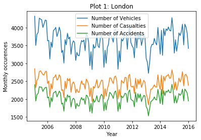

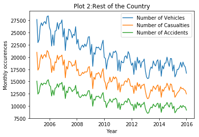

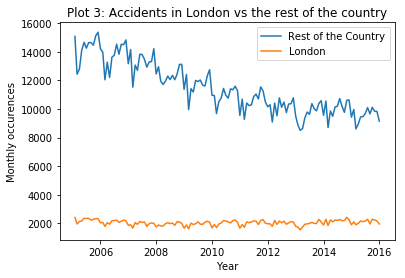

| Year | Accidents London | Accidents Rest | Vehicles London | Vehicles Rest | Casualties London | Casualties Rest |
| --- | --- | --- | --- | --- | --- | --- |
| 2005 | 26812 | 171894 | 48371 | 317816 | 31905 | 239082 |
| 2015 | 25232 | 114806 | 45047 | 212765 | 30231 | 155936 |

```python
### PLOTS
# Number of monthly accidents, casualties, and vehicles involved graphed over time for London
fig, fig1 = plt.subplots(1, 1)
fig1.plot(accidents_ldn[['Number_of_Vehicles', 'Number_of_Casualties', 'Accident_Index']].resample('m').agg({'Number_of_Vehicles':'sum', 'Number_of_Casualties':'sum', 'Accident_Index':'count'}))
fig1.legend(('Number of Vehicles', 'Number of Casualties', 'Number of Accidents'))
fig1.set_ylabel("Monthly occurences")
fig1.set_xlabel("Year")
fig1.set_title('Plot 1: London')
plt.show()

# Number of monthly accidents, casualties, and vehicles involved graphed over time for the rest of the Country
fig, fig1 = plt.subplots(1, 1)
fig1.plot(accidents_not_ldn[['Number_of_Vehicles', 'Number_of_Casualties', 'Accident_Index']].resample('m').agg({'Number_of_Vehicles':'sum', 'Number_of_Casualties':'sum', 'Accident_Index':'count'}))
fig1.legend(('Number of Vehicles', 'Number of Casualties', 'Number of Accidents'))
fig1.set_ylabel("Monthly occurences")
fig1.set_xlabel("Year")
fig1.set_title('Plot 2:Rest of the Country')
plt.show()

# Number of monthly accidents in London vs the rest of the country
fig, fig2 = plt.subplots(1, 1)
fig2.plot(accidents_not_ldn[['Accident_Index']].resample('M').agg({'Accident_Index':'count'}),label='Rest of the Country')
fig2.plot(accidents_ldn[['Accident_Index']].resample('M').agg({'Accident_Index':'count'}),label='London')
fig2.set_ylabel("Monthly occurences")
fig2.set_xlabel("Year")
fig2.set_title('Plot 3: Accidents in London vs the rest of the country')
fig2.legend()
plt.show()

### TABLE
# Goal of table: Shows the absolute number of accidents, casualties and vehicles in London vs the rest side by side
# Resample dataframes to annual frequency
yearly_accidents_ldn = accidents_ldn[['Accident_Index','Number_of_Casualties','Number_of_Vehicles']].resample('a').agg({'Accident_Index':'count','Number_of_Vehicles':'sum', 'Number_of_Casualties':'sum'})
yearly_accidents = accidents_not_ldn[['Accident_Index','Number_of_Casualties','Number_of_Vehicles']].resample('a').agg({'Accident_Index':'count','Number_of_Vehicles':'sum', 'Number_of_Casualties':'sum'})

# change column names to faciliate merging of the two dataframes
yearly_accidents_ldn.columns = ['Accidents in London', 'Casualties in London', 'Vehicles involved in London']
yearly_accidents.columns = ['Accidents (UK except London)', 'Casualties (UK except London)', 'Vehicles involved (UK except London)']

# merge the two dataframes and change column order
combine = [yearly_accidents_ldn,yearly_accidents]
combines_yearly_accidents = pd.concat(combine,axis=1)
cols = ['Accidents in London', 'Accidents (UK except London)', 'Casualties in London', 'Casualties (UK except London)', 'Vehicles involved in London', 'Vehicles involved (UK except London)']
combines_yearly_accidents = combines_yearly_accidents[cols]

# change index
combines_yearly_accidents.index = combines_yearly_accidents.index.year
combines_yearly_accidents.index.rename('Year', inplace=True)

# introduce multi-hierarchical column headers
index = [['Accidents','Accidents','Vehicles','Vehicles','Casualties','Casualties'],['London','Rest','London','Rest','London','Rest']]
combines_yearly_accidents.columns = index
endpoints = pd.concat([combines_yearly_accidents.iloc[:1,:],combines_yearly_accidents.iloc[-1:,:]],axis=0)
endpoints
```

## Question 1 Takeaways:

- Plot 1 above shows that the number of accidents, casualties and vehicles **involved fluctuates a lot within years, but has remained somewhat stable over the 10 years overall.**
- It shows a downward trend for the years 2005-10, but in the time 2010-15 it has risen back to 2005 levels.
- This stands in contrast to the trend we see in Plot 2 for the rest of the country, where all three metrics show a clear downward trend.
- Over ten years, the number of **accidents per year in London has decreased from 26,812 to 25,232 whereas it has decreased from 171,894 to 114,806 in the Rest of the country, a very large difference!**
- This poses the question - what is the reason that accidents have decreased in the rest of the country but remained stable in London?

## Question 2: Did accidents increase relative to the population?

Question 1 underlined the need to look at accident numbers in relative terms. In this section, we compare the number of accidents over time to the population growth.

#### Question 2 Analysis

| Year | Accidents/Pop in London | Accidents/Pop Rest of UK |
| --- | --- | --- |
| 2005 | 0.356590 | 0.335950 |
| 2015 | 0.290902 | 0.210326 |

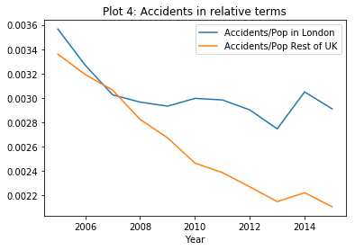

```python
# import and reshape population data
population = pd.read_excel("./data/Data_FULL-2005-2015/ons-mye-population-totals.xls")

population.index= population['Year']
population = population.drop(columns='Year')
population.columns = ['Pop_LDN','Pop_GB']

# merge population data to yearly number of accidents
combine = [combines_yearly_accidents,population]
accidents_population = pd.concat(combine,axis=1)

# compute relative number of accidents
accidents_population['Pop_Rest'] = accidents_population['Pop_GB']-accidents_population['Pop_LDN']
accidents_population['Accidents/Pop in London'] = accidents_population[('Accidents', 'London')]/accidents_population['Pop_LDN']
accidents_population['Accidents/Pop Rest of UK'] = accidents_population[('Accidents', 'Rest')]/accidents_population['Pop_Rest']

### PLOT
accidents_population['Accidents/Pop in London'].plot()
accidents_population['Accidents/Pop Rest of UK'].plot()
plt.legend()
plt.title('Plot 4: Accidents in relative terms')

### TABLE
endpoints = pd.concat([accidents_population.iloc[:1,-2:]*100,accidents_population.iloc[-1:,-2:]*100],axis=0)
endpoints
```

## Question 3: Did accidents increase relative to the kilometers travelled?

Another 'driver' of the number of traffic accidents is the amount of kilometers travelled by traffic participants. The more people use road transport, the more accidents we expect. Therefore, I now put the number of traffic accidents into context with the number of kilometers travelled.

#### Question 3 Analysis

| Year | Accidents/bn motor vehicle km in London | Accidents/bn motor vehicle km in Rest of UK |
| --- | --- | --- |
| 2005 | 853.885350 | 57.971892 |
| 2015 | 864.109589 | 52.511967 |

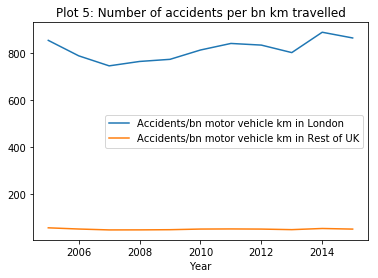

```python
# import and reshape road usage data
kilometers = pd.read_excel("./data/Data_FULL-2005-2015/kilometers_import.xlsx")

kilometers['Year'] = pd.to_datetime(kilometers.Year,format='%Y')
kilometers.index = kilometers['Year']
kilometers.index = kilometers.index.year
kilometers = kilometers.drop(columns='Year')

# create data frame that allows subtracting road usage in London from the rest of the GB to get the road usage for the 'rest of the country'
kilometers_ldn = kilometers[(kilometers.Region == 'London')].drop(columns='Region')
kilometers_gb = kilometers[(kilometers.Region == 'Great Britain')].drop(columns='Region')
kilometers_not_ldn = kilometers[(kilometers.Region == 'Great Britain')].drop(columns='Region').sub(kilometers[(kilometers.Region == 'London')]).drop(columns='Region')
kilometers_ldn = kilometers_ldn.reindex(sorted(kilometers_ldn.columns), axis=1)

# merge road usage data to yearly number of accidents
accidents_kilometers_temp = pd.merge(combines_yearly_accidents, kilometers_ldn, on='Year')

# re-label the columns
index = pd.Series(accidents_kilometers_temp.columns[-8:])
new_index = pd.Series(['Accidents_Ldn','Accidents_Rest','Vehicles_London','Vehicles_Rest','Casualties_Ldn','Casualties_Rest'])
index_temp = pd.Series(['LDN'] * 8)
new_index1 = index[-8:] + "_" + index_temp
index_temp = pd.Series(['Rest'] * 8)
new_index2 = index[-8:] + "_" + index_temp
merged_index = pd.concat([new_index, new_index1, new_index2], axis=0)

# cast the dataframe for analysis using re-labelled columns and merged data
accidents_kilometers = pd.merge(accidents_kilometers_temp, kilometers_not_ldn, on='Year')
accidents_kilometers.columns = merged_index

# compute number of accidents relative to the number of kilometers travelled
accidents_kilometers['Accidents/bn motor vehicle km in London'] = accidents_kilometers['Accidents_Ldn']/accidents_kilometers['All motor vehicles_LDN']
accidents_kilometers['Accidents/bn motor vehicle km in Rest of UK'] = accidents_kilometers['Accidents_Ldn']/accidents_kilometers['All motor vehicles_Rest']

### PLOTS
accidents_kilometers['Accidents/bn motor vehicle km in London'].plot()
accidents_kilometers['Accidents/bn motor vehicle km in Rest of UK'].plot()
plt.legend()
plt.title('Plot 5: Number of accidents per bn km travelled')

### TABLE
# This table compares the endpoints of the timeseries
endpoints = pd.concat([accidents_kilometers.iloc[:1,-2:],accidents_kilometers.iloc[-1:,-2:]],axis=0)
endpoints
```

## Question 4: Which traffic participants are most vulnerable?

We already learned that life on the road in London is much more dangerous than in the rest of the country. But who is most vulnerable to the danger of traffic accidents?

#### Question 4 Analysis

| Year | Buses & Coaches_LDN | Cars and taxis_LDN | Heavy Goods Vehicles_LDN | Light Commercial Vehicles_LDN | Motorcycles_LDN | Pedal Cyclists_LDN |
| --- | --- | --- | --- | --- | --- | --- |
| 2005 | 0.6 | 25.1 | 1.1 | 3.8 | 0.8 | 0.55 |
| 2015 | 0.5 | 22.8 | 1.0 | 4.2 | 0.6 | 0.60 |

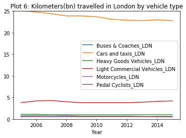

```python
### PLOT
# Using the road usage data, I plot the kilometers travelled by vehicle to shed light on risk exposure by vehicle
accidents_kilometers.iloc[:,7:13].plot()
plt.ylim(bottom=0,top=25)
plt.title('Plot 6: Kilometers(bn) travelled in London by vehicle type')

### TABLE
# This table compares the endpoints of the timeseries
endpoints2 = pd.concat([accidents_kilometers.iloc[:1,7:13],accidents_kilometers.iloc[-1:,7:13]],axis=0)
endpoints2
```

```
Text(0.5,1,'Plot 7: Kilometers(bn) travelled in London by vehicle type, excluding cars')
```

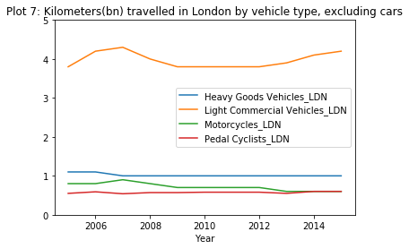

```python
### PLOT
# Same as plot 6 but zoomed in on vehicles other than cars
accidents_kilometers.iloc[:,9:13].plot()
plt.ylim(bottom=0,top=5)
plt.title('Plot 7: Kilometers(bn) travelled in London by vehicle type, excluding cars')
```

```
Text(0.5,1,'Plot 8: Number of accidents in London by vehicle type')
```

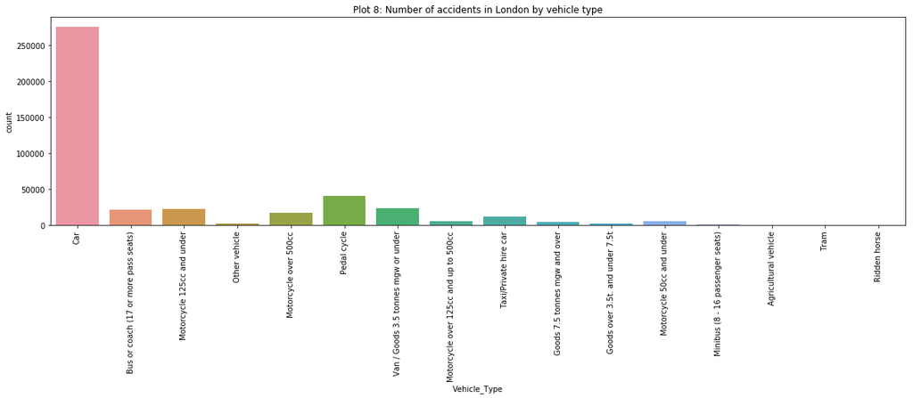

```python
### PLOT
# Which vehicle type was involved in most accidents
fig, ax = plt.subplots()
fig.set_size_inches(20, 5)
sns.countplot(x=accidents_vehicles_ldn.Vehicle_Type)
plt.xticks(rotation=90)
plt.title('Plot 8: Number of accidents in London by vehicle type')
```

```
Text(0.5,1,'Plot 9: Number of casualties in London by casualty type')
```

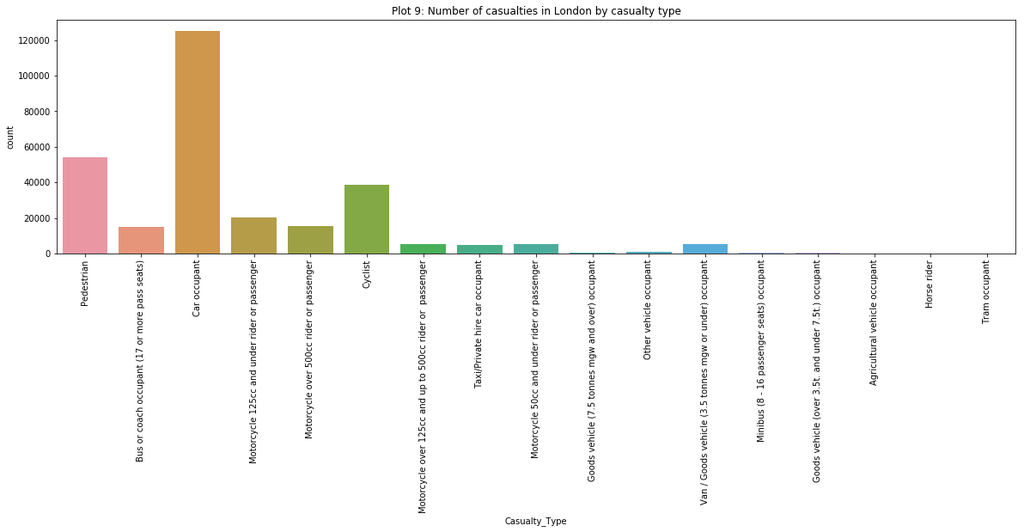

```python
# Who were the most common casualties?
fig, ax = plt.subplots()
fig.set_size_inches(20, 5)
sns.countplot(x=accidents_casualties_ldn.Casualty_Type)
plt.xticks(rotation=90)
plt.title('Plot 9: Number of casualties in London by casualty type')
```

```
Text(0.5,1,'Plot 10: Number of fatal casualties in London by casualty type')
```

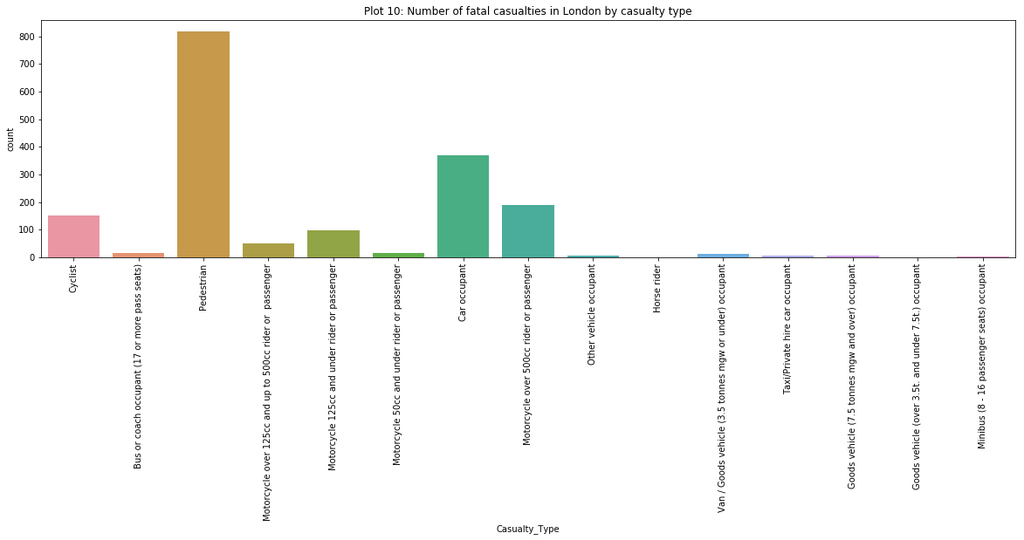

```python
# Who were the most common fatalities?
fig, ax = plt.subplots()
fig.set_size_inches(20, 5)
sns.countplot(x=accidents_casualties_ldn.Casualty_Type[accidents_casualties_ldn.Casualty_Severity=='Fatal'])
plt.xticks(rotation=90)
plt.title('Plot 10: Number of fatal casualties in London by casualty type')
```

## Question 4 Takeaways:

- The number of kilometers travelled by road is a measure of risk exposure. Plot 6, 7 and the corresponding enpoint table show a **decrease in road usage for all categories except for light commerical vehicles and pedal cyclists.**
- In plot 8 we see how the risk exposure translates into accident involvement by vehicle type. Cars are involved in the highest number of accidents. Motorcycles and pedal cycles have a high number of accidents relative to their road usage.
- When it comes to casualties of an accident, pedestrians enter the picture. **After car occupants, pedestrians are the most common casualties together with pedal cyclists.**
- The vulnerability of **pedestrians** is even clearer when looking at **fatal accidents**, where they represent the largest casualty group.

## Question 5: Do we observe a change in the type of casualty over time?

I now study whether there is a casualty group for whom road transport has become relatively less safe over time, focussing on the three main casualty types established in the above section: pedestrians, car occupants, and pedal cyclists.

#### Question 5 Analysis

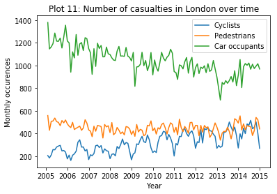

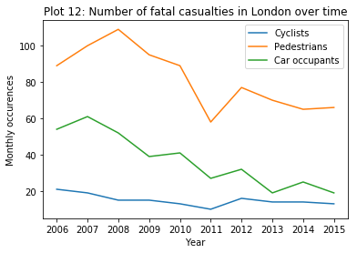

```python
# sets the date-time object as the index of our dataframe
accidents_casualties_ldn['DateTime'] = pd.to_datetime(accidents_casualties_ldn.Date + " " +  accidents_casualties_ldn.Time)
accidents_casualties_ldn.index = accidents_casualties_ldn['DateTime']

### PLOT
# Plot for all accidents
# Filter dataset by casualty type
accidents_casualties_ldn_filter1 = accidents_casualties_ldn[accidents_casualties_ldn.Casualty_Type == 'Cyclist']
accidents_casualties_ldn_filter2 = accidents_casualties_ldn[accidents_casualties_ldn.Casualty_Type == 'Pedestrian']
accidents_casualties_ldn_filter3 = accidents_casualties_ldn[accidents_casualties_ldn.Casualty_Type == 'Car occupant']
# draw plot
fig, fig3 = plt.subplots(1, 1)
fig3.plot(accidents_casualties_ldn_filter1[['Casualty_Type']].resample('M').agg({'Casualty_Type':'count'}),label='Cyclists')
fig3.plot(accidents_casualties_ldn_filter2[['Casualty_Type']].resample('M').agg({'Casualty_Type':'count'}),label='Pedestrians')
fig3.plot(accidents_casualties_ldn_filter3[['Casualty_Type']].resample('M').agg({'Casualty_Type':'count'}),label='Car occupants')
fig3.legend()
fig3.set_ylabel("Monthly occurences")
fig3.set_xlabel("Year")
fig3.set_title('Plot 11: Number of casualties in London over time')
plt.show()

# Plot for fatal accidents
# Filter dataset by casualty type
accidents_casualties_ldn_filter1 = accidents_casualties_ldn[(accidents_casualties_ldn.Casualty_Type == 'Cyclist') & (accidents_casualties_ldn.Casualty_Severity == 'Fatal')]
accidents_casualties_ldn_filter2 = accidents_casualties_ldn[(accidents_casualties_ldn.Casualty_Type == 'Pedestrian') & (accidents_casualties_ldn.Casualty_Severity == 'Fatal')]
accidents_casualties_ldn_filter3 = accidents_casualties_ldn[(accidents_casualties_ldn.Casualty_Type == 'Car occupant') & (accidents_casualties_ldn.Casualty_Severity == 'Fatal')]
# draw plot
fig, fig3 = plt.subplots(1, 1)
fig3.plot(accidents_casualties_ldn_filter1[['Casualty_Type']].resample('a').agg({'Casualty_Type':'count'}),label='Cyclists')
fig3.plot(accidents_casualties_ldn_filter2[['Casualty_Type']].resample('a').agg({'Casualty_Type':'count'}),label='Pedestrians')
fig3.plot(accidents_casualties_ldn_filter3[['Casualty_Type']].resample('a').agg({'Casualty_Type':'count'}),label='Car occupants')
fig3.legend()
fig3.set_ylabel("Monthly occurences")
fig3.set_xlabel("Year")
fig3.set_title('Plot 12: Number of fatal casualties in London over time')
plt.show()
```

## Question 5 Takeaways:

- As shown in plot 11, **the number of car occupants becoming casualties in accidents in London has gone down markedly** over the period 2005-15.
- This stands **in contrast to the number of casualties among pedal cyclists, which has gone up**, while the number of pedestrian casualties has remained more or less at the same level
- On the positive side, the number of car occupant, cyclist and pedestrian casualties that resulted in deaths has gone down on year-on-year comparison, as shown in plot 12

## Question 6: What kind of demographics do casualties have?

We already found out that, in relative terms, life on London roads is most dangerous for cyclists and pedestrians. I now study whether there is a certain demographic amongst pedestrians and cyclist where casualty numbers are particularly high.

#### Question 6 Analysis

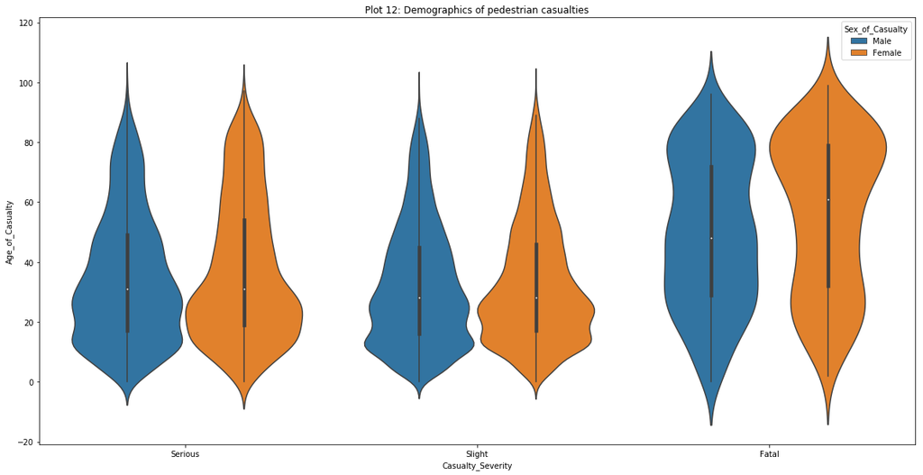

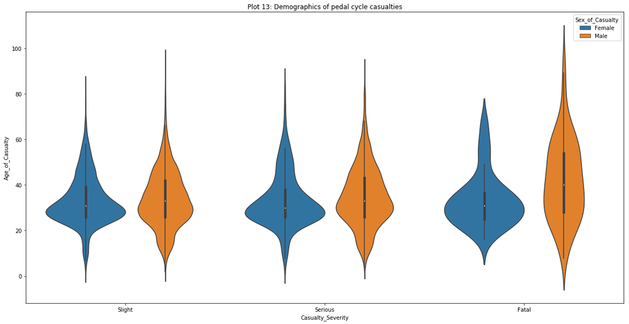

```python
### PLOTS
# Demographics of pedestrian casualties
fig, ax = plt.subplots()
fig.set_size_inches(20, 10)
ax.set_title('Plot 12: Demographics of pedestrian casualties')
sns.violinplot(x="Casualty_Severity", y="Age_of_Casualty" ,hue = "Sex_of_Casualty", data = accidents_casualties_ldn[(accidents_casualties_ldn["Age_of_Casualty"]>-1)&(accidents_casualties_ldn["Casualty_Type"]=="Pedestrian")])

# Demographics of pedal cycle casualties
fig, ax = plt.subplots()
fig.set_size_inches(20, 10)
ax.set_title('Plot 13: Demographics of pedal cycle casualties')
sns.violinplot(x="Casualty_Severity", y="Age_of_Casualty" ,hue = "Sex_of_Casualty", data = accidents_casualties_ldn[(accidents_casualties_ldn["Age_of_Casualty"]>-1)&(accidents_casualties_ldn["Casualty_Type"]=="Cyclist")])
```

## Question 7: What are risk factors for pedestrians?

Having studied the demographics of victims, I now look at potential risk factors. In which situations do most accidents occur? In this report I zero in on pedestrians and cyclists, because in relative terms, they are the most vulnerable. I start with studying the situation for pedestrians.

#### Question 7 Analysis

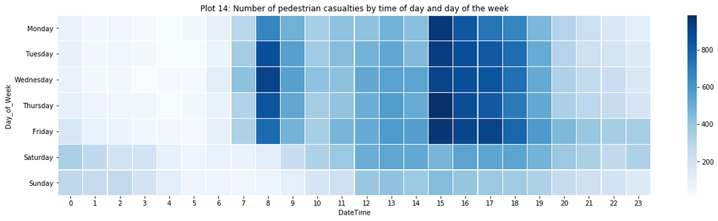

```python
### PLOTS
# heatmap for pedestrian casualties by time of day and day of the week
accidents_casualties_ldn.index = accidents_casualties_ldn['DateTime']
accidents_ldn_day_time = accidents_casualties_ldn[(accidents_casualties_ldn.Casualty_Class=='Pedestrian')]
accidents_ldn_day_time = accidents_ldn_day_time.groupby(['Day_of_Week',accidents_ldn_day_time.index.hour]).agg({'Number_of_Casualties':'sum'})
accidents_ldn_day_time = pd.pivot_table(accidents_ldn_day_time,values='Number_of_Casualties',index='Day_of_Week',columns='DateTime')
accidents_ldn_day_time = accidents_ldn_day_time.loc[['Monday','Tuesday','Wednesday','Thursday','Friday','Saturday','Sunday'],:]
fig, ax = plt.subplots()
fig.set_size_inches(20, 5)
ax.set_title('Plot 14: Number of pedestrian casualties by time of day and day of the week')
sns.heatmap(accidents_ldn_day_time,linewidths=.2, cmap="Blues")
```

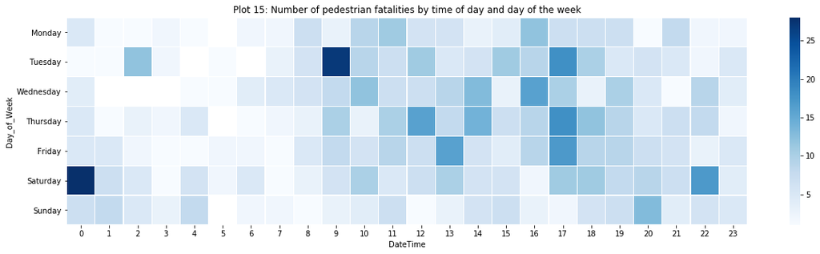

```python
# heatmap for fatal pedestrian casualties by time of day and day of the week
accidents_ldn_day_time = accidents_casualties_ldn[(accidents_casualties_ldn.Casualty_Severity=='Fatal') & (accidents_casualties_ldn.Casualty_Class=='Pedestrian')]
accidents_ldn_day_time = accidents_ldn_day_time.groupby(['Day_of_Week',accidents_ldn_day_time.index.hour]).agg({'Number_of_Casualties':'sum'})
accidents_ldn_day_time = pd.pivot_table(accidents_ldn_day_time,values='Number_of_Casualties',index='Day_of_Week',columns='DateTime')
accidents_ldn_day_time = accidents_ldn_day_time.loc[['Monday','Tuesday','Wednesday','Thursday','Friday','Saturday','Sunday'],:]
fig, ax = plt.subplots()
fig.set_size_inches(20, 5)
ax.set_title('Plot 15: Number of pedestrian fatalities by time of day and day of the week')
sns.heatmap(accidents_ldn_day_time,linewidths=.2, cmap="Blues")
```

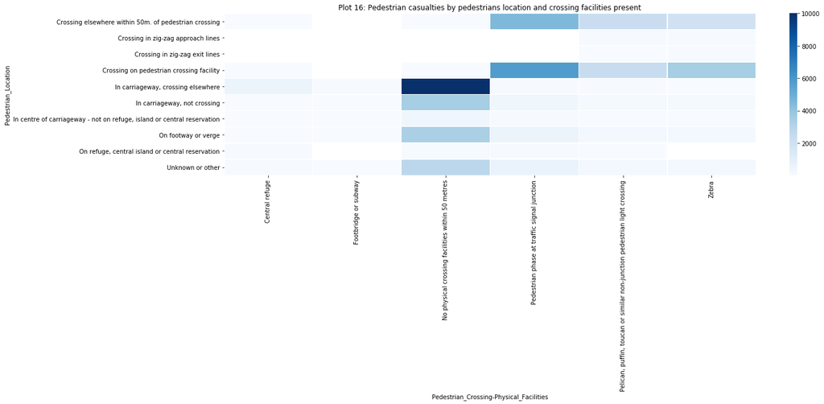

```python
# heatmap for pedestrian casualties by pedestrians location and crossing facilities present
accidents_ldn_day_time = accidents_casualties_ldn[(accidents_casualties_ldn.Casualty_Class=='Pedestrian')]
accidents_ldn_day_time = accidents_ldn_day_time.groupby(["Pedestrian_Crossing-Physical_Facilities",'Pedestrian_Location']).agg({'Number_of_Casualties':'sum'})
accidents_ldn_day_time = pd.pivot_table(accidents_ldn_day_time,values='Number_of_Casualties',index="Pedestrian_Location",columns='Pedestrian_Crossing-Physical_Facilities')
fig, ax = plt.subplots()
fig.set_size_inches(20, 5)
ax.set_title('Plot 16: Pedestrian casualties by pedestrians location and crossing facilities present')
sns.heatmap(accidents_ldn_day_time,linewidths=.2, cmap="Blues",vmax=10000)
```

[figure not shown]

```python
# heatmap for pedestrian casualties by pedestrians movement at the time of the accident and age band of casualty
heatmap = accidents_casualties_ldn[(accidents_casualties_ldn.Casualty_Class=='Pedestrian')].groupby(["Pedestrian_Location","Pedestrian_Movement"]).agg({"Casualty_Type":"count"})
heatmap = pd.pivot_table(heatmap,values='Casualty_Type',index='Pedestrian_Movement',columns='Pedestrian_Location')
fig, ax = plt.subplots()
fig.set_size_inches(20, 5)
ax.set_title('Plot 17: Pedestrian casualties by pedestrians movement at the time of the accident and age band of casualty')
sns.heatmap(heatmap,linewidths=.2, cmap="Blues", vmax=10000)
```

[figure not shown]

```python
# heatmap for pedestrian casualties by pedestrians location and age band of casualty
heatmap = accidents_casualties_ldn[(accidents_casualties_ldn.Casualty_Class=='Pedestrian')].groupby(["Age_Band_of_Casualty","Pedestrian_Location"]).agg({"Casualty_Type":"count"})
heatmap = pd.pivot_table(heatmap,values='Casualty_Type',index='Pedestrian_Location',columns='Age_Band_of_Casualty')
fig, ax = plt.subplots()
fig.set_size_inches(20, 5)
ax.set_title('Plot 18: Pedestrian casualties by pedestrians location and crossing facilities present')
sns.heatmap(heatmap,linewidths=.2, cmap="Blues")
```

## Question 8: What are the risk factors for cyclists fatalities?

Having studied the situtations in which pedestrian casualties occured, I now turn to cyclist casualties, the second most common casualty type.

#### Question 8 Analysis

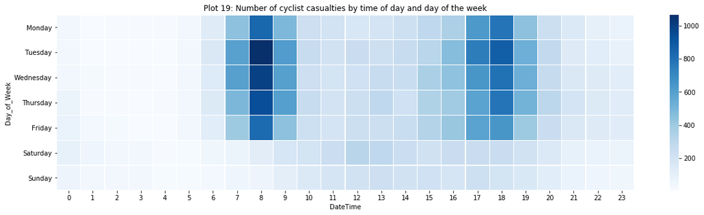

```python
###PLOTS
# heatmap for cyclist casualties by time of day and day of the week
accidents_casualties_ldn.index = accidents_casualties_ldn['DateTime']
accidents_ldn_day_time = accidents_casualties_ldn[(accidents_casualties_ldn.Casualty_Type=='Cyclist')]
accidents_ldn_day_time = accidents_ldn_day_time.groupby(['Day_of_Week',accidents_ldn_day_time.index.hour]).agg({'Number_of_Casualties':'sum'})
accidents_ldn_day_time = pd.pivot_table(accidents_ldn_day_time,values='Number_of_Casualties',index='Day_of_Week',columns='DateTime')
accidents_ldn_day_time = accidents_ldn_day_time.loc[['Monday','Tuesday','Wednesday','Thursday','Friday','Saturday','Sunday'],:]
fig, ax = plt.subplots()
fig.set_size_inches(20, 5)
ax.set_title('Plot 19: Number of cyclist casualties by time of day and day of the week')
sns.heatmap(accidents_ldn_day_time,linewidths=.2, cmap="Blues")
```

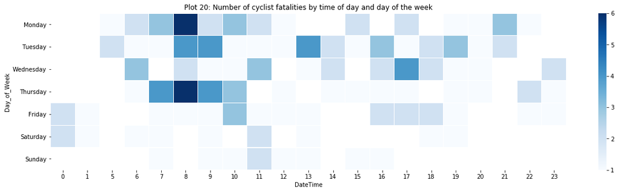

```python
# heatmap for cyclist fatalities by time of day and day of the week
accidents_casualties_ldn.index = accidents_casualties_ldn['DateTime']
accidents_ldn_day_time = accidents_casualties_ldn[(accidents_casualties_ldn.Casualty_Severity=='Fatal') & (accidents_casualties_ldn.Casualty_Type=='Cyclist')]
accidents_ldn_day_time = accidents_ldn_day_time.groupby(['Day_of_Week',accidents_ldn_day_time.index.hour]).agg({'Number_of_Casualties':'sum'})
accidents_ldn_day_time = pd.pivot_table(accidents_ldn_day_time,values='Number_of_Casualties',index='Day_of_Week',columns='DateTime')
accidents_ldn_day_time = accidents_ldn_day_time.loc[['Monday','Tuesday','Wednesday','Thursday','Friday','Saturday','Sunday'],:]
fig, ax = plt.subplots()
fig.set_size_inches(20, 5)
ax.set_title('Plot 20: Number of cyclist fatalities by time of day and day of the week')
sns.heatmap(accidents_ldn_day_time,linewidths=.2, cmap="Blues")
```

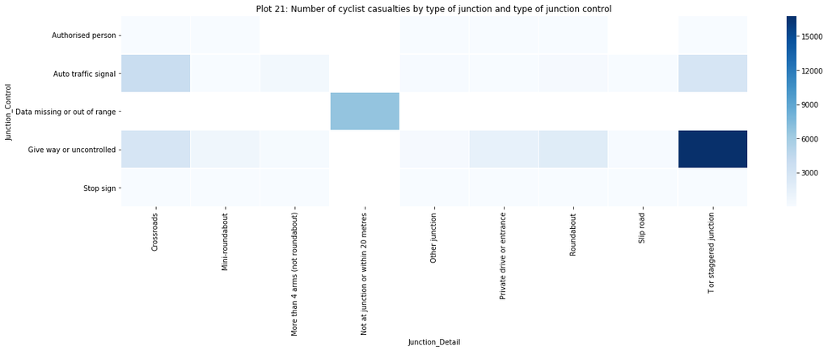

```python
# heatmap of number of cyclist casualties by type of junction and type of junction control
heatmap = accidents_casualties_ldn[(accidents_casualties_ldn.Casualty_Type=='Cyclist')].groupby(["Junction_Detail","Junction_Control"]).agg({"Casualty_Type":"count"})
heatmap = pd.pivot_table(heatmap,values='Casualty_Type',index='Junction_Control',columns='Junction_Detail')
fig, ax = plt.subplots()
fig.set_size_inches(20, 5)
ax.set_title('Plot 21: Number of cyclist casualties by type of junction and type of junction control')
sns.heatmap(heatmap,linewidths=.2, cmap="Blues")
```

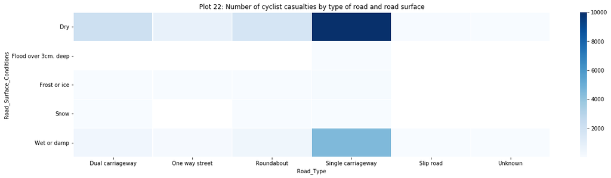

```python
# heatmap of number of cyclist casualties by type of road and road surface
heatmap = accidents_casualties_ldn[(accidents_casualties_ldn.Casualty_Type=='Cyclist')].groupby(["Road_Type","Road_Surface_Conditions"]).agg({"Casualty_Type":"count"})
heatmap = pd.pivot_table(heatmap,values='Casualty_Type',index='Road_Surface_Conditions',columns='Road_Type')
fig, ax = plt.subplots()
fig.set_size_inches(20, 5)
ax.set_title('Plot 22: Number of cyclist casualties by type of road and road surface')
sns.heatmap(heatmap,linewidths=.2, cmap="Blues",vmax=10000)
```

## Question 8 Takeaways:

- Mondays it might be difficult to get out of bed, but on Tuesdays it seems most dangerous! If you are a cyclist in London, that is. For some reason, Tuesday mornings we see particularly many accidents with cyclist casualties.
- Cyclist casualties' distribution across time is similar to pedestrians', but **accidents with cyclists in the afternoon happen a bit later (6pm rather than 3-6pm), and we do not see a second peak on weekend mornings,** as we did for pedestrians.
- Fortunately, the **number of recorded cyclist fatalities is not that large, so the distribution is less clear**. Plot 20 shows that most however are clustered around the morning hours (8am), rather than the afternoon.
- Plot 21 shows us that **cyclist casualties occur mostly at uncontrolled T-junctions with give-way rules or completely away from junctions.**
- Road surface conditions are important for cyclists's ability to break unexpectedly. In plot 22 we see that **a significant amount of accidents happen when it is wet, and on narrow single carriageways.**

## Question 9: Should we focus on any specific location and time?

Now that we have learned about the circumstances of accidents in London, and the demographics of casualties, we want to find out whether any part of the city records particularly many accidents, and whether that differs according to the day of the week.

#### Question 9 Analysis

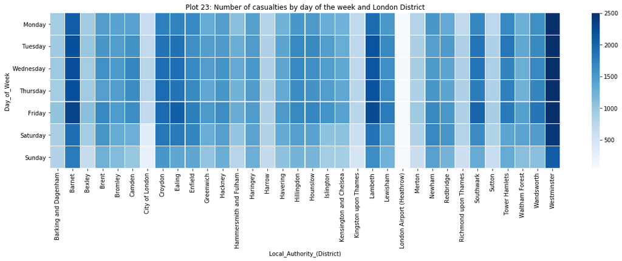

```python
# heatmap number of casualties by day of the week and London District
accidents_ldn_day = accidents_ldn.groupby(['Day_of_Week','Local_Authority_(District)']).agg({'Number_of_Casualties':'sum'})
accidents_ldn_day = pd.pivot_table(accidents_ldn_day,values='Number_of_Casualties',index='Day_of_Week',columns='Local_Authority_(District)')
accidents_ldn_day = accidents_ldn_day.loc[['Monday','Tuesday','Wednesday','Thursday','Friday','Saturday','Sunday'],:]
fig, ax = plt.subplots()
fig.set_size_inches(20, 5)
ax.set_title('Plot 23: Number of casualties by day of the week and London District')
sns.heatmap(accidents_ldn_day,linewidths=.2, cmap="Blues",vmax=2500)
```

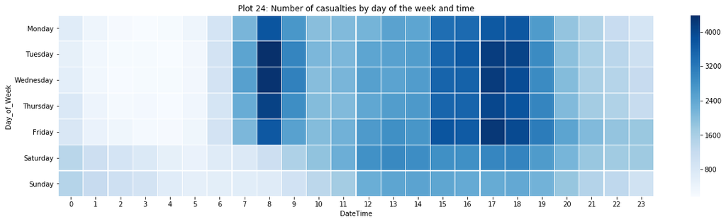

```python
# heatmap number of casualties by day of the week and time
accidents_ldn.index = accidents_ldn['DateTime']
accidents_ldn_day_time = accidents_ldn.groupby(['Day_of_Week',accidents_ldn.index.hour]).agg({'Number_of_Casualties':'sum'})
accidents_ldn_day_time = pd.pivot_table(accidents_ldn_day_time,values='Number_of_Casualties',index='Day_of_Week',columns='DateTime')
accidents_ldn_day_time = accidents_ldn_day_time.loc[['Monday','Tuesday','Wednesday','Thursday','Friday','Saturday','Sunday'],:]
fig, ax = plt.subplots()
fig.set_size_inches(20, 5)
ax.set_title('Plot 24: Number of casualties by day of the week and time')
sns.heatmap(accidents_ldn_day_time,linewidths=.2, cmap="Blues")
```

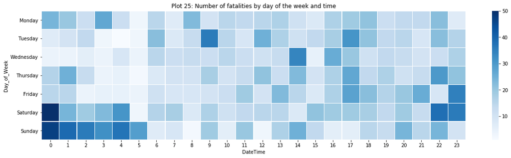

```python
# heatmap number of fatalities by day of the week and time
accidents_casualties_ldn.index = accidents_casualties_ldn['DateTime']
accidents_ldn_fatal = accidents_casualties_ldn[accidents_casualties_ldn.Casualty_Severity =='Fatal']
accidents_ldn_fatal = accidents_ldn_fatal.groupby(['Day_of_Week',accidents_ldn_fatal.index.hour]).agg({'Number_of_Casualties':'sum'})
accidents_ldn_fatal = pd.pivot_table(accidents_ldn_fatal,values='Number_of_Casualties',index='Day_of_Week',columns='DateTime')
accidents_ldn_fatal = accidents_ldn_fatal.loc[['Monday','Tuesday','Wednesday','Thursday','Friday','Saturday','Sunday'],:]
fig, ax = plt.subplots()
fig.set_size_inches(20, 5)
ax.set_title('Plot 25: Number of fatalities by day of the week and time')
sns.heatmap(accidents_ldn_fatal,linewidths=.2, cmap="Blues", vmax=50)
```

## Question 9 Takeaways:

- Districts with a particularly high number of casualties in absolute terms are **Westminster, Lambeth and Barnet**. Casualties occur mostly during the weekdays in these hotspots.
- In plot 24 I revisit the distribution of casualties by the day of the week and time of day, but now looking at all types of casualties.
- I contrast this with the distribution of fatalities across the day of the week and time of day in Plot 25, which shows that **fatalities are clustered around Saturday and Sunday mornings. So weekend nights are particularly dangerous for all traffic participants, not only pedestrians.**

## Question 10: What type of fatal accidents happen in the early morning hours?

Given that fatalities are clustered around the early morning hours, I now look into the type of fatalities we find at these hours.

#### Question 10 Analysis

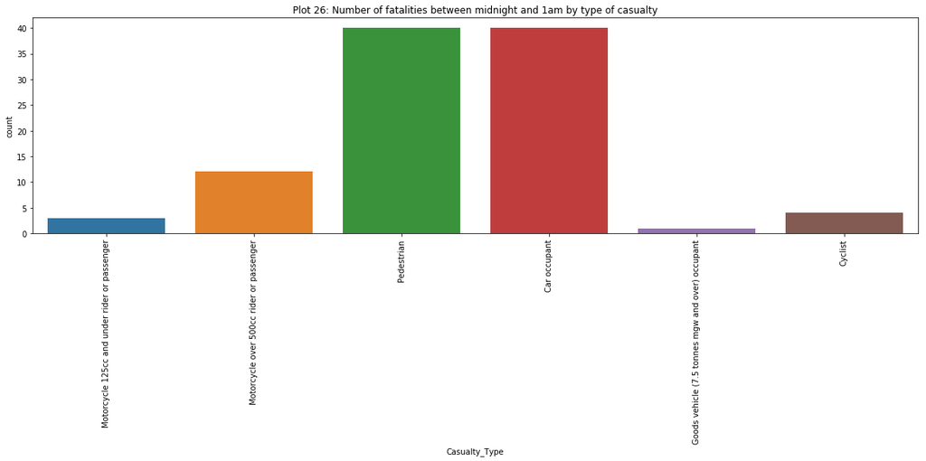

```python
# countplot of number of fatalities by casualty type filtered for time between midnight and 1am
accidents_ldn_fatal = accidents_casualties_ldn[(accidents_casualties_ldn.Casualty_Severity =='Fatal') & (accidents_casualties_ldn.index.hour==0)]
fig, ax = plt.subplots()
fig.set_size_inches(20, 5)
ax.set_title('Plot 26: Number of fatalities between midnight and 1am by type of casualty')
sns.countplot(x=accidents_ldn_fatal.Casualty_Type)
plt.xticks(rotation=90)
```

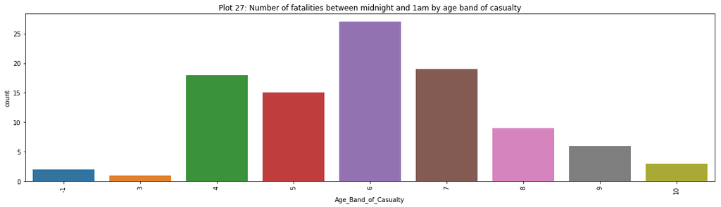

```python
# countplot of number of fatalities by age band filtered for time between midnight and 1am
accidents_ldn_fatal = accidents_casualties_ldn[(accidents_casualties_ldn.Casualty_Severity =='Fatal') & (accidents_casualties_ldn.index.hour==0)]
fig, ax = plt.subplots()
fig.set_size_inches(20, 5)
ax.set_title('Plot 27: Number of fatalities between midnight and 1am by age band of casualty')
sns.countplot(x=accidents_ldn_fatal.Age_Band_of_Casualty)
plt.xticks(rotation=90)
```

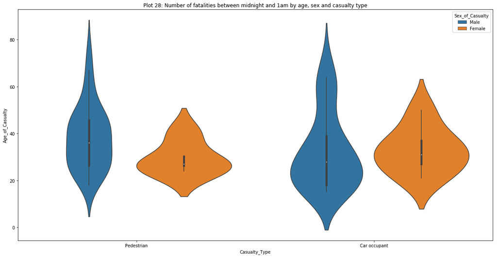

```python
# violinplot of number of fatalities by age, sex and casualty type filtered for time between midnight and 1am, and for car occupants and pedestrians
fig, ax = plt.subplots()
fig.set_size_inches(20, 10)
ax.set_title('Plot 28: Number of fatalities between midnight and 1am by age, sex and casualty type')
sns.violinplot(x="Casualty_Type", y="Age_of_Casualty" ,hue = "Sex_of_Casualty", data = accidents_casualties_ldn[(accidents_casualties_ldn["Age_of_Casualty"]>-1)&(accidents_casualties_ldn.Casualty_Severity =='Fatal') & (accidents_casualties_ldn.index.hour==0)&((accidents_casualties_ldn.Casualty_Type =='Car occupant')|(accidents_casualties_ldn.Casualty_Type =='Pedestrian'))])
```

## Question 10 Takeaways:

- **Most fatalities between midnight and 1am are car occupants and pedestrians** (Plot 26). Compared to other times in the day, we see much less cyclists (Plot 26).
- In terms of age groups, **25 to 35 year olds make up the largest group of fatalities between midnight and 1am** (Plot 27).
- Plot 28 shows a **significant difference between sex in terms of the age of fatalities' casualties in the hours midnight to 1am**. Among pedestrian casualties, female casualties are on average younger than male casualties, whereas among car occupants, male victims are on average younger.

## Conclusions

First of all, I wish to congratulate the mayor of London for requesting a report on road safety in the city. Contrary to expectation, road safety has not improved when compared with the number of kilometers travelled! While the number of accidents has remained relatively stable in the face of a population increase, the number of accidents relative to the number of kilometers travelled as increased in the face of a reduction of road traffic in London. Meanwhile, in the rest of the country, road safety has improved by all measures - # of accidents, # of accidents/pop and # of accidents/km travelled.

Studying the accidents from 2005-15 in London closer, we find that cars travel the highest number of kilometers among vehicles on London roads, therefore have the highest accident exposure, and also end up getting into the highest number of accidents among all traffic participants. When looking at the casualties from accidents however, the number of pedestrian and cyclist casualties is relatively larger. This further intensifies when looking at fatal accidents, where pedestrians make up the largest number. Looking at the number of casualties over time further reveals that while casualties of car occupants has gone down, cyclist casualties have gone up (and pedestrian casualties remained at the 2005 level)! Improving the safety of pedestrians and cyclists therefore appears a promising lever to improve overall road safety.

The higest number of early weekend morning fatalities is found for car occupants and pedestrians in the age of 25-35. Interestingly, female pedestrian fatalities are younger than male pedestrian fatalities on average, whereas female car occupant fatalities are older than male car occupant fatalities. In any case, it appears that the rate of fatalities on early weekend mornings provides another arguement to keep the tube running longer!